# rdwd: climate data from the German Weather Service

Berry Boessenkool, berry-b@gmx.de

2019-07-15

[Vignette Rmd source code](https://github.com/brry/rdwd/blob/master/misc/vign/rdwd.Rmd) (Not on CRAN to reduce load on DWD server through daily new builds and checks of the vignette)  
Interactive map vignette  
use cases vignette

*Links to the function help pages lead to 404 on CRAN, but work in locally opened vignettes.*

### Intro

The [R](https://www.r-project.org/) package [`rdwd`](https://github.com/brry/rdwd#rdwd) contains code to select, download and read weather data from measuring stations across Germany. The German Weather Service (Deutscher Wetterdienst, DWD) provides thousands of datasets with weather observations through the FTP server online at

ftp://opendata.dwd.de/climate_environment/CDC/observations_germany/climate.

For data interpolated onto a 1 km raster, including radar data up to the last hour, see ftp://opendata.dwd.de/climate_environment/CDC/grids_germany/. Raster and binary reading functions for the Radolan data are included in `rdwd` since May 2019.

For further details, please consult the DWD FTP server documentation  
Please note that, as of June 2019, the old server at ftp://ftp-cdc.dwd.de will be phased out.

### Package structure

To use the observation datasets, `rdwd` has been designed to mainly do 3 things:

- `selectDWD`: facilitate file selection, e.g. for certain station names (with `findID`), by geographical location (see map and `nearbyStations`), by temporal resolution (**res** = 1/10 minutes, hourly, daily, monthly, annual), variables (**var** = temperature, rain, wind, sun, clouds, etc) or observation period (**per** = historical long term records or the current year)
- `dataDWD`: download a file (or multiple files, without getting banned by the FTP-server)
- `readDWD`: read that data into R (including useful defaults for metadata)

`selectDWD` uses the result from `indexFTP` which recursively lists all the files on an FTP-server (using RCurl::getURL). As this is time consuming, the result is stored in the package dataset `fileIndex`. From this, `metaIndex` and `geoIndex` are derived.

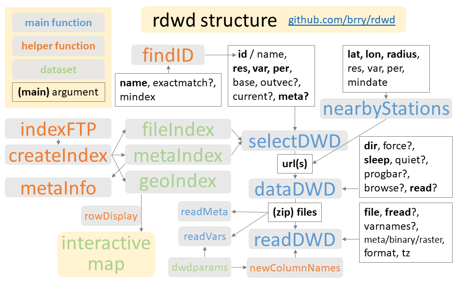

TOC

### Package installation

```r
install.packages("rdwd")
# get the latest development version from github, incl. vignettes:
remotes::install_github("brry/rdwd", build_opts="--no-manual")
# For full usage, as needed in indexFTP and selectDWD(..., current=TRUE):
install.packages("RCurl") # is only suggested, not mandatory dependency
```

On Linux, instead of the last line above, use in the terminal (with lowercase rcurl):

```
sudo apt-get install r-cran-rcurl
```

If direct installation from CRAN doesn’t work, your R version might be too old. In that case you’ll need to [update R](https://github.com/brry/course#install).

TOC

### Basic usage

```r
library(rdwd)
link <- selectDWD("Potsdam", res="daily", var="kl", per="recent")
file <- dataDWD(link, read=FALSE, dir="../localdata", quiet=TRUE, force=NA)
clim <- readDWD(file, varnames=TRUE)

str(clim)
```

```
## 'data.frame':    550 obs. of  19 variables:
##  $ STATIONS_ID               : int  3987 3987 3987 3987 3987 3987 3987 3987 3987 3987 ...
##  $ MESS_DATUM                : POSIXct, format: "2018-01-11" "2018-01-12" ...
##  $ QN_3                      : int  10 10 10 10 10 10 10 10 10 10 ...
##  $ FX.Windspitze             : num  5 9.9 12.2 10.4 16.3 16.6 13.6 25.7 9.4 6.8 ...
##  $ FM.Windgeschwindigkeit    : num  1.5 3.9 5.2 5 5.8 6.1 5.7 8 3.7 3.4 ...
##  $ QN_4                      : int  3 3 3 3 3 3 3 3 3 3 ...
##  $ RSK.Niederschlagshoehe    : num  1.4 0 0 0 4.1 1.3 2.7 5.9 2.2 0.3 ...
##  $ RSKF.Niederschlagsform    : int  6 6 7 0 8 6 8 8 8 7 ...
##  $ SDK.Sonnenscheindauer     : num  0 0 0 7.18 5.03 ...
##  $ SHK_TAG.Schneehoehe       : int  0 0 0 0 0 2 0 2 0 0 ...
##  $ NM.Bedeckungsgrad         : num  8 8 7.7 3.3 5.8 7 6.3 7.5 7.6 6.5 ...
##  $ VPM.Dampfdruck            : num  6.6 6.8 5 4.2 4.7 6.9 6 6.4 6.6 6.2 ...
##  $ PM.Luftdruck              : num  1005 1016 1019 1016 1002 ...
##  $ TMK.Lufttemperatur        : num  1.1 1.5 0 -1.9 0.1 2.3 0.8 2 1.8 0.5 ...
##  $ UPM.Relative_Feuchte      : num  100 99.1 81.5 79.9 76.8 ...
##  $ TXK.Lufttemperatur_Max    : num  2.5 2.2 0.6 0.5 3 5 2 5.2 3.6 2.8 ...
##  $ TNK.Lufttemperatur_Min    : num  -0.3 0.6 -0.4 -3.4 -2.8 0.2 -1.1 0.3 -0.3 -1.1 ...
##  $ TGK.Lufttemperatur_5cm_min: num  -1 0.4 -0.7 -5.9 -4.8 -1.4 -3.4 -1.2 -2 -2 ...
##  $ eor                       : Factor w/ 1 level "eor": 1 1 1 1 1 1 1 1 1 1 ...
```

TOC

### Plotting examples

Recent temperature time series:

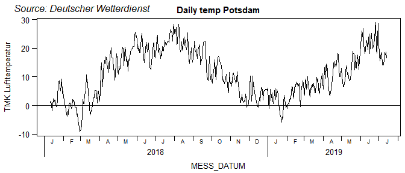

```r
par(mar=c(4,4,2,0.5), mgp=c(2.7, 0.8, 0), cex=0.8)
plot(clim[,c(2,14)], type="l", xaxt="n", las=1, main="Daily temp Potsdam")
berryFunctions::monthAxis()   ;   abline(h=0)
mtext("Source: Deutscher Wetterdienst", adj=-0.1, line=0.5, font=3)
```

Long term climate graph:

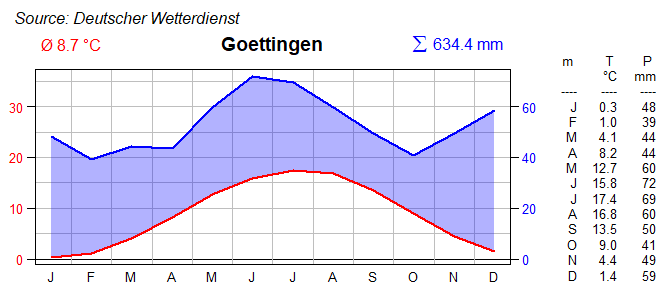

```r
link <- selectDWD("Goettingen", res="monthly", var="kl", per="h")
clim <- dataDWD(link, quiet=TRUE, dir="../localdata")
clim$month <- substr(clim$MESS_DATUM_BEGINN,5,6)
temp <- tapply(clim$MO_TT, clim$month, mean, na.rm=TRUE)
prec <- tapply(clim$MO_RR, clim$month, mean, na.rm=TRUE)
berryFunctions::climateGraph(temp, prec, main="Goettingen")
mtext("Source: Deutscher Wetterdienst", adj=-0.05, line=2.8, font=3)
```

TOC

### Station selection

Weather stations can be selected geographically with the interactive map. All stations within a certain radius around a given lat-long position can be obtained with nearbyStations.

The DWD station IDs can be obtained from station names with

```r
findID("Potsdam")
```

```
## Potsdam
##    3987
```

```r
findID("Koeln", exactmatch=FALSE)
```

```
##               Koeln-Bonn Koeln-Botanischer Garten           Koeln-Porz-Eil
##                     2667                     2665                     2666
##          Koeln-Stammheim
##                     2968
```

TOC

### Available files

File selection by station name/id and folder happens with `selectDWD`. It needs an index of all the available files on the server. The package contains such an index (`fileIndex`) that is updated (at least) with each CRAN release of the package. The selectDWD documentation contains an overview of the FTP folder structure.

If you find the file index to be outdated (Error in download.file … : cannot open URL), please let me know and I will update it. Meanwhile, use current=TRUE in `selectDWD`:

```r
# all files at a given path, with current file index (RCurl required):
links <- selectDWD(res="monthly", var="more_precip", per="hist", current=TRUE)
```

`fileIndex` is created with the function `indexFTP` used in the last section of [rdwd-package.R](https://github.com/brry/rdwd/blob/master/R/rdwd-package.R#L249).

```r
### This chunk is not evaluated ###
# recursively list files on the FTP-server:
files <- indexFTP("hourly/sun") # use dir="some_path" to save the output elsewhere
berryFunctions::headtail(files, 5, na=TRUE)

# indexFTP uses a folder to resume indexing after getting banned:
radfiles <- indexFTP("hourly/radolan/recent", gridbase)
radfiles <- indexFTP(radfiles,gridbase, sleep=1)

# with other FTP servers, this should also work...
funet <- indexFTP(base="ftp.funet.fi/pub/standards/w3/TR/xhtml11/", folder="")
p <- RCurl::getURL(    "ftp.funet.fi/pub/standards/w3/TR/xhtml11/",
                       verbose=T, ftp.use.epsv=TRUE, dirlistonly=TRUE)
```

TOC

### File selection

`selectDWD` is designed to be very flexible:

```r
# inputs can be vectorized, and period can be abbreviated:
selectDWD(c("Potsdam","Wuerzburg"), res="hourly", var="sun", per="hist")
```

```
## [[1]]
## [1] "ftp://opendata.dwd.de/climate_environment/CDC/observations_germany/climate/hourly/sun/historical/ stundenwerte_SD_03987_18930101_20181231_hist.zip"
##
## [[2]]
## [1] "ftp://opendata.dwd.de/climate_environment/CDC/observations_germany/climate/hourly/sun/historical/ stundenwerte_SD_05705_19510101_20181231_hist.zip"
```

If res/var/per are left NA, an interactive selection is opened with the available options for the given station.

```r
# Time period can be doubled to get both filenames:
selectDWD("Potsdam", res="daily", var="kl", per="rh")
```

```
## [1] "ftp://opendata.dwd.de/climate_environment/CDC/observations_germany/climate/daily/kl/recent/tageswerte_KL_03987_akt.zip"
## [2] "ftp://opendata.dwd.de/climate_environment/CDC/observations_germany/climate/daily/kl/historical/tageswerte_KL_03987_18930101_20181231_hist.zip"
```

There may be a differing number of available files for several stations across all folders. That’s why the default outvec is FALSE (unless `per="hr"`).

```r
lapply(selectDWD(id=c(3467,5116), res="",var="",per=""), substr, 76, 1e4)
```

```
## [[1]]
## [1] "annual/more_precip/historical/jahreswerte_RR_03467_19930101_20181231_hist.zip"
## [2] "annual/more_precip/recent/jahreswerte_RR_03467_akt.zip"
## [3] "daily/more_precip/historical/tageswerte_RR_03467_19930601_20181231_hist.zip"
## [4] "daily/more_precip/recent/tageswerte_RR_03467_akt.zip"
## [5] "monthly/more_precip/historical/monatswerte_RR_03467_19930601_20171231_hist.zip"
## [6] "monthly/more_precip/historical/monatswerte_RR_03467_19930601_20181231_hist.zip"
## [7] "monthly/more_precip/recent/monatswerte_RR_03467_akt.zip"
##
## [[2]]
## [1] "annual/more_precip/historical/jahreswerte_RR_05116_19920101_20061231_hist.zip"
## [2] "daily/more_precip/historical/tageswerte_RR_05116_19920701_20061231_hist.zip"
## [3] "monthly/more_precip/historical/monatswerte_RR_05116_19920701_20061231_hist.zip"
```

TOC

### Metadata

`selectDWD` also uses a complete data.frame with meta information, `metaIndex` (derived from the “Beschreibung” files in `fileIndex`).

```r
# All metadata at all folders:
data(metaIndex)
str(metaIndex, vec.len=2)
```

```
## 'data.frame':    96609 obs. of  12 variables:
##  $ Stations_id  : int  1 1 1 1 1 ...
##  $ von_datum    : int  18910101 18910101 18910101 18910101 19120101 ...
##  $ bis_datum    : int  19860630 19860630 19860630 19860630 19860630 ...
##  $ Stationshoehe: num  478 478 478 478 478 ...
##  $ geoBreite    : num  47.8 47.8 ...
##  $ geoLaenge    : num  8.85 8.85 ...
##  $ Stationsname : chr  "Aach" "Aach" ...
##  $ Bundesland   : chr  "Baden-Wuerttemberg" "Baden-Wuerttemberg" ...
##  $ res          : chr  "annual" "annual" ...
##  $ var          : chr  "more_precip" "more_precip" ...
##  $ per          : chr  "historical" "recent" ...
##  $ hasfile      : logi  TRUE FALSE TRUE ...
```

```r
View(data.frame(sort(unique(rdwd:::metaIndex$Stationsname)))) # ca 6k entries
```

`dataDWD` can download (and `readDWD` can correctly read) such a data.frame from any folder on the FTP server:

```r
# file with station metadata for a given path:
m_link <- selectDWD(res="monthly", var="more_precip", per="hist", meta=TRUE)
substr(m_link, 76, 1e4) # (Monatswerte = monthly values, Beschreibung = description)
```

```
## [1] "monthly/more_precip/historical/RR_Monatswerte_Beschreibung_Stationen.txt"
```

```r
meta_monthly_rain <- dataDWD(m_link) # not executed in vignette creation
str(meta_monthly_rain)
```

Meta files may list stations for which there are actually no files. These refer to nonpublic datasets (The DWD cannot publish all datasets because of copyright restrictions). To request those, please contact cdc.daten@dwd.de or klima.vertrieb@dwd.de.

TOC

Any feedback on this package (or this vignette) is very welcome via [github](https://github.com/brry/rdwd) or berry-b@gmx.de!